# L11 Functions and Iteration

Data Science 1 with R (STAT 301-1)

Author

Allison Kane

**Github Repo Link**

[Allison Github Link](https://github.com/stat301-1-2023-fall/L11-functions-iteration-akane2460.git)

## Packages & Datasets

Datasets referenced in this lab are from the `palmerpenguins` and `mpg` packages.

```r
# Loading package(s)

library(palmerpenguins)
library(tidyverse)
library(lubridate)
library(forcats)
```

## Exercises

### Exercise 1

Practice turning the following code snippets into functions. Think about what each function does. What would you call it? How many arguments does it need?

```r
# function 1
mean(is.na(x))

# function 2
x / sum(x, na.rm = TRUE)

# function 3
round(x / sum(x, na.rm = TRUE) * 100, 1)
```

**Solution**

```r
# label: ex-01 solution

# function 1
function_1 <- function(x) {mean(is.na(x))}

# function 2
function_2 <- function(x) {x / sum(x, na.rm = TRUE)}

# function 3
function_3 <- function(x) {round(x / sum(x, na.rm = TRUE) * 100, 1)}
```

### Exercise 2

Write a function that returns how old you are in years, given your birthday (as `"YYYY-MM-DD"`).

**Solution**

```r
age_years <- function(x) {interval(ymd(x), today()) |>  as.period() |>  year()}
```

### Exercise 3

Write a function that computes the mean, standard deviation, and count given a dataset and a numeric variable.

Test your function using the `penguins` dataset and a numeric variable of your choice.

**Solution**

```r
dataset_summary <- function(df, variable) {
  df |> summarize(mean = mean(variable, na.rm = TRUE),
                  sd = sd(variable, na.rm = TRUE),
                  n = n())}

dataset_summary(penguins, penguins$body_mass_g)
```

```
# A tibble: 1 × 3
   mean    sd     n
  <dbl> <dbl> <int>
1 4202.  802.   344
```

### Exercise 4

Write a function that counts the number of missing observations given a dataset and a variable.

Test your function using the `penguins` dataset and a variable of your choice.

**Solution**

```r
dataset_missing <- function(df, variable) {
  df |>
    filter(is.na(variable) == TRUE) |>
    summarize(
    number_missing = n()
  )
}

# Test your function using the `penguins` dataset and a variable of your choice.
dataset_missing(penguins, penguins$body_mass_g)
```

```
# A tibble: 1 × 1
  number_missing
           <int>
1              2
```

### Exercise 5

Write a function that draws a scatterplot given a dataset and x and y variables. Add a line of best fit and an appropriate title to the plot.

Test your function using the `penguins` dataset and an x and y variable of your choice.

**Solution**

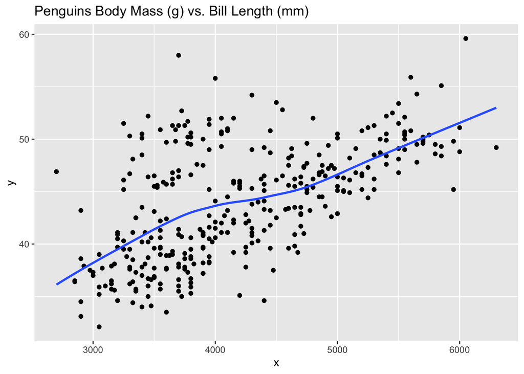

```r
scatterplot <- function(df, x, y, title) {
  df |>
    ggplot(aes(x = x, y = y)) +
    geom_point() +
    geom_smooth(method = loess, se = FALSE) +
    labs(title = title)}

scatterplot(penguins, penguins$body_mass_g, penguins$bill_length_mm, "Penguins Body Mass (g) vs. Bill Length (mm)")
```

### Exercise 6

Use the `across()` function to…

1. compute the number of unique values in each column of `penguins`
2. compute the `mean` of every numeric column of `penguins`.

**Solution**

```r
# a) compute the number of unique values in each column of `penguins`

penguins |>
  summarize(across(everything(), n_distinct))
```

```
# A tibble: 1 × 8
  species island bill_length_mm bill_depth_mm flipper_length_mm body_mass_g
    <int>  <int>          <int>         <int>             <int>       <int>
1       3      3            165            81                56          95
# ℹ 2 more variables: sex <int>, year <int>
```

```r
# b) compute the mean of every numeric column of penguins.

penguins |>
  summarize(across(where(is.numeric), ~ mean(., na.rm = TRUE)))
```

```
# A tibble: 1 × 5
  bill_length_mm bill_depth_mm flipper_length_mm body_mass_g  year
           <dbl>         <dbl>             <dbl>       <dbl> <dbl>
1           43.9          17.2              201.       4202. 2008.
```

### Exercise 7

Write code that uses one of the map functions to:

1. compute the number of unique values in each column of `penguins`
2. compute the `mean` of numeric every column in `penguins`.

**Solution**

```r
# a)
number_unique <- function(df) {
  df |>
    summarize(across(everything(), n_distinct))
}

# b)

means_numeric <- function(df) {
  df |>
    summarize(
      means = across(where(is.numeric), ~ mean(., na.rm = TRUE)))
}
```

### Exercise 8

Write a `for` loop that uses your function in Exercise 3 to compute the mean, standard deviation, and count of every numeric variable in the `penguins` dataset.

Output the results as a nicely formatted table.

**Solution**

```r
dataset_summary <- function(df, variable) {
  df |> summarize(mean = mean(variable, na.rm = TRUE),
                  sd = sd(variable, na.rm = TRUE),
                  n = n())}

list_of_summaries <- list()

for (col in names(penguins)) {
  ifelse(is.numeric(penguins[[col]]) == TRUE,
         list_of_summaries[[col]] <- dataset_summary(penguins, penguins[[col]]),
         col_nonnumeric <- col
  )

}

as.tibble(list_of_summaries)
```

```
# A tibble: 1 × 5
  bill_length_mm$mean bill_depth_mm$mean flipper_length_mm$mean body_mass_g$mean
                <dbl>              <dbl>                  <dbl>            <dbl>
1                43.9               17.2                   201.            4202.
# ℹ 9 more variables: bill_length_mm$sd <dbl>, $n <int>,
#   bill_depth_mm$sd <dbl>, $n <int>, flipper_length_mm$sd <dbl>, $n <int>,
#   body_mass_g$sd <dbl>, $n <int>, year <tibble[,3]>
```

### Exercise 9

Write a `for` loop that plots the distribution of each variable in the `penguins` dataset and saves each plot to a `\plots` subdirectory.

Hint: need to determine if a variable is numeric or categorical to determine the appropriate plot.

**Solution**

```r
numeric_plot <- function(df, variable) {
  ggplot(data = df, aes(x = {{variable}})) +
    geom_histogram(stat = "count") +
    labs(
      title = "Distribution"
    )
}

categorical_plot <- function(df, variable) {
  ggplot(data = df, aes(x = {{variable}})) +
    geom_bar() +
    labs(
      title = "Distribution"
    )
}

for (col in names(penguins)) {
  filename <- str_c("plots/", col, "distribution.png", sep = "")

  ifelse(is.numeric(penguins[[col]]) == TRUE,
         plot <- numeric_plot(penguins, col),
         plot <- categorical_plot(penguins, col)
         )

  ggsave(filename, plot)
}
```

### Exercise 10

Determine which variables in the `mpg` dataset should be factors and convert them to factors using a `for` loop.

**Solution**

```r
variables_to_factor <- c("manufacturer", "model", "drv", "trans", "class")

for (var in variables_to_factor) {
  mpg[[var]] <- as_factor(mpg[[var]])
}
```

### Exercise 11

The `data` subdirectory has various CSV files that you want to read in.

First, store their paths in a vector: `files <- dir("data/", pattern = "\\.csv$", full.names = TRUE)`.

1. Write a for loop that will read in each file individually.
2. Write a for loop that will load the files into a single data frame.

**Solution**

```r
# First, store their paths in a vector: `files <- dir("data/", pattern = "\\.csv$", full.names = TRUE)`.

# a) Write a for loop that will read in each file individually.

files <- dir("data/", pattern = "\\.csv$", full.names = TRUE)

individual_files <- list()

for (file in files) {
  individual_files[[file]] <- read.csv(file)
}

# b) Write a for loop that will load the files into a single data frame.

single_frame <- list()

for (file in files) {
  df <- read_csv(file)
  single_frame <- append(single_frame, list(df))
}

single_frame <- bind_rows(single_frame)
```